# Clustering: PAM k-Medoids, CLARA & Silhouette Values

Joseph Bolton

09 April, 2020

Clustering algorithms are for partitioning objects into groups, such that similar objects get assigned to the same group.

In this post, I briefly explain the PAM Partitioning Around Medoids algorithm, implementing it from scratch in R on a simple 2-dimensional dataset. My result is identical to the result obtained by the R function pam() in the *cluster* package.

# Partitioning Around Medoids

The PAM algorithm chooses $k$ points/rows in the data to be *medoids*, or *cluster centres*. The value $k$ is a parameter that must be chosen (this can be chosen using *Silhouette* values, which are discussed later on in this post). For each *non-medoid* point/row in the data, cluster membership is decided according to which *medoid* that point is closest to.

PAM consists of 2 phases: a BUILD phase and a SWAP phase.

In the BUILD phase, $k$ initial *medoid* points are chosen.

In the SWAP phase, different *medoid* points are tried, until an optimal clustering is achieved.

I don’t describe or implement the BUILD phase (which is very simple) in this post, simply choosing random starting *medoids*. Further details can be found in the original paper:

$\quad$ *Clustering by Means of Medoids*

$\quad$ Leonard KAUFMAN & Peter J. Rousseeuw

$\quad$ https://www.researchgate.net/publication/243777819_Clustering_by_Means_of_Medoids

$$\space \quad \space$$

Here is a simple 2-dimensional 100-observation dataset of random noise, for us to test out PAM clustering on:

```r
x <- runif(100, -100, 100 )
y <- runif(100, -100, 100 )

thedata <- tibble( x = x,
                   y = y
                 )

thedata
```

| x | y |
| --- | --- |
| -19.367835 | 63.605740 |
| 60.685921 | 36.710630 |
| 41.005901 | 15.244587 |
| -25.453459 | -23.256562 |
| 58.057042 | 96.526656 |
| 77.831933 | -19.557689 |
| -68.457521 | 53.994196 |
| -28.284993 | -28.537205 |
| -84.224858 | 89.679209 |
| 75.557717 | 2.854529 |

[output cut: 90 more lines]

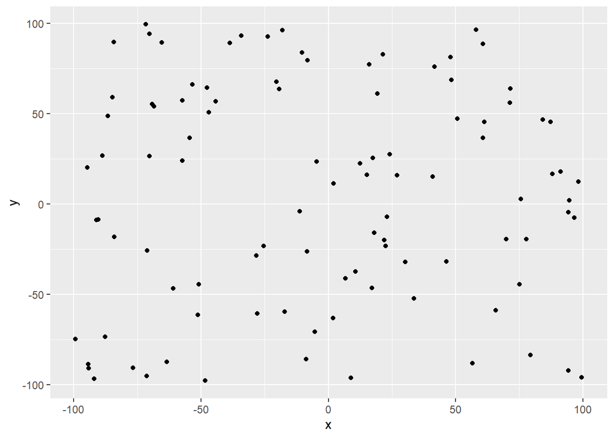

```r
ggplot( data = thedata,
        aes( x=x, y=y)
      ) +
  geom_point()
```

The PAM algorithm is as follows:

- We wish to define *k* clusters, where the value of *k* is prespecified by the user.

**BUILD STEP**

- Choose *k* data points to be the starting *medoids* (I have skipped this step and simply chosen random starting *medoid* points, but this would not be difficult to code).
- Each *medoid* point represents, in a sense, the *centre* of a cluster.
- For each point, assign that point to it’s closest *medoid* point. This is how clusters are decided. I measured distance using the ‘euclidean’ distance measure, although another distance measure could have been used.
- The sum of the distances of each point to it’s assigned *medoid* (i.e. tightness of clusters) measures the quality of a given clustering.

**SWAP STEP**

- For each *medoid* point, do the following:
  - swap this *medoid* point with any *non-medoid* point (i.e. the *non-medoid* point becomes a *medoid* point and the *medoid* point becomes a *non-medoid* point)
  - reassign every point to it’s closest *medoid*. Calculate the sum of distances of each point to it’s closest *medoid*.
- Amongst all the swaps considered above, find the swap that resulted in the smallest sum of distances of each point to it’s closest *medoid*.
- If the best swap gives a smaller sum of distances to closest *medoid* than we’ve seen before (i.e. the clustering improved), then do this swap.
- Keep repeating this swap step until the clustering can not be improved (i.e. sum of distances of each point to it’s closest *medoid* can’t be reduced). This is the final clustering.

# PAM using cluster package in R

Here is how the PAM algorithm can be implemented automatically in R (still using the dataset created above):

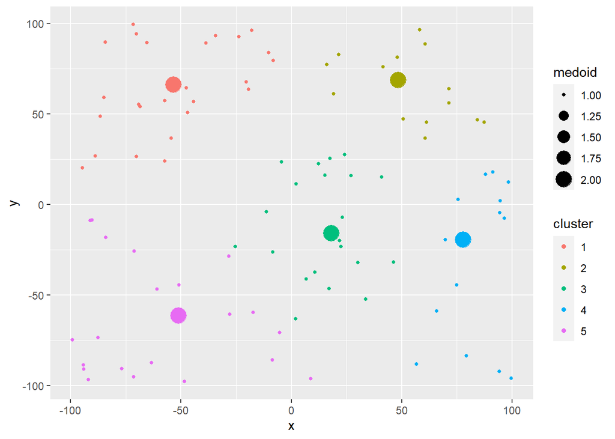

```r
k <- 5   # k is a number that we must choose
init_medoids <- sample( 1:nrow(thedata), size=k )   # give random starting medoids

run_pam <- cluster::pam( x = thedata,
                         k = k,
                         metric = "euclidean",
                         diss = FALSE,
                         medoids = init_medoids,
                         stand = FALSE,
                         pamonce = 0
                      )

ggplot( data = bind_cols( thedata, tibble( cluster = factor(run_pam$clustering) ) ) %>%
                  mutate( id = row_number() ) %>%
                  mutate( medoid = ifelse(id %in% run_pam$id.med, 2, 1) )
          ,
        aes( x=x, y=y, colour=cluster, size=medoid )
      ) +
  geom_point() +
  theme( legend.position = NULL )
```

Note that we have chosen $k=5$ clusters. $k$ is a hyperparameter that we ourselves must choose for this algorithm. Some methods for choosing $k$ are discussed later.

# PAM from scratch

Now, I implement the PAM algorithm (performed above automatically) from scratch:

specify $k$ = number of clusters:

```r
k <- 5
```

specify initial (random) medoids to the algorithm:

```r
init_medoids <- init_medoids      # use the same random starting medoids we used earlier
```

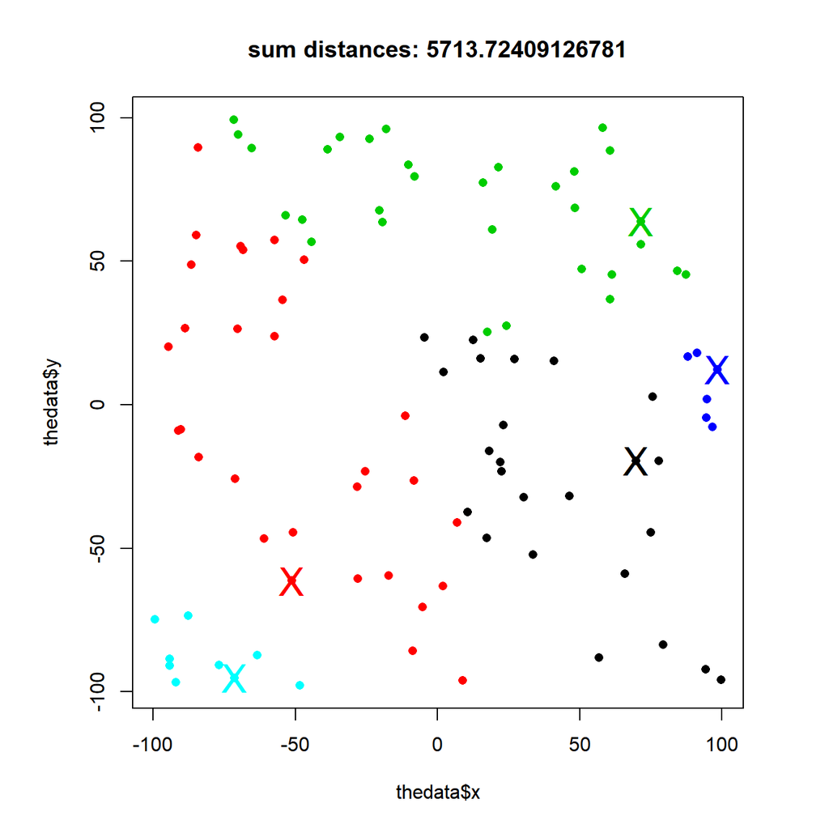

```r
par( pty="s")

n <- nrow(thedata)

distmat <- dist(thedata, method="euclidean") %>% as.matrix()
cluster_vec <- rep(NA, nrow(distmat) )
dist_from_medoid_vec <- rep(NA, nrow(distmat) )

# create a function which returns sum of distances of
# all points to their nearest medoid:

calc_tot_within_dist <- function(medoid_indices){

  for( p in 1:length(cluster_vec) ){

    # assign each point to a cluster based on closest medoid:
    # and store this information
    cluster_vec[p] <- which.min( distmat[p,medoid_indices] )

    # calculate the distance of each point from it's assigned medoid:
    # and store this information
    dist_from_medoid_vec[p] <- distmat[p, medoid_indices[cluster_vec[p]] ]

  }

  return(
          list( tot_dist = sum(dist_from_medoid_vec),
                cluster_vec = cluster_vec,
                dist_from_medoid_vec = dist_from_medoid_vec
              )
        )


}

# give my alg the same starting medoids as I gave to cluster::pam():
current_medoid_indices <- init_medoids

# define a plotting function:
draw_current_plot <- function(){
    plot( x = thedata$x,
          y = thedata$y,
          col = run_dist_calc$cluster_vec,
          pch = 16,
          main = paste0( "sum distances: ", run_dist_calc$tot_dist )
    )
    points( x = thedata$x[current_medoid_indices],
            y = thedata$y[current_medoid_indices],
            col = run_dist_calc$cluster_vec[current_medoid_indices],
            pch = "X",
            cex = 2
          )
    # text( x = thedata$x,
    #       y = thedata$y,
    #       col = run_dist_calc$cluster_vec,
    #       labels = round(run_dist_calc$dist_from_medoid_vec, digits=2),
    #       pos = 2,
    #       cex = 0.8
    # )
}

# plot the starting situation:
run_dist_calc <- calc_tot_within_dist( medoid_indices = current_medoid_indices )
draw_current_plot()
```

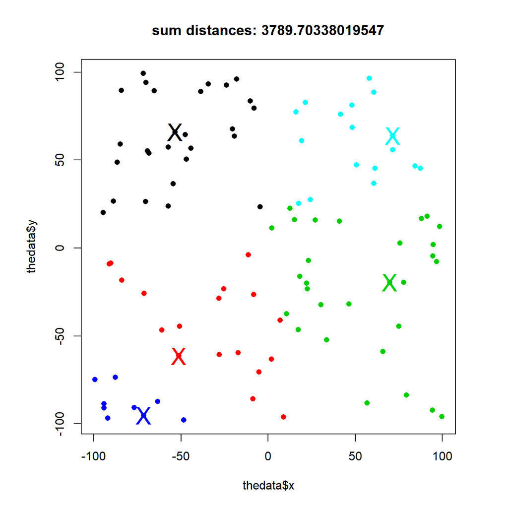

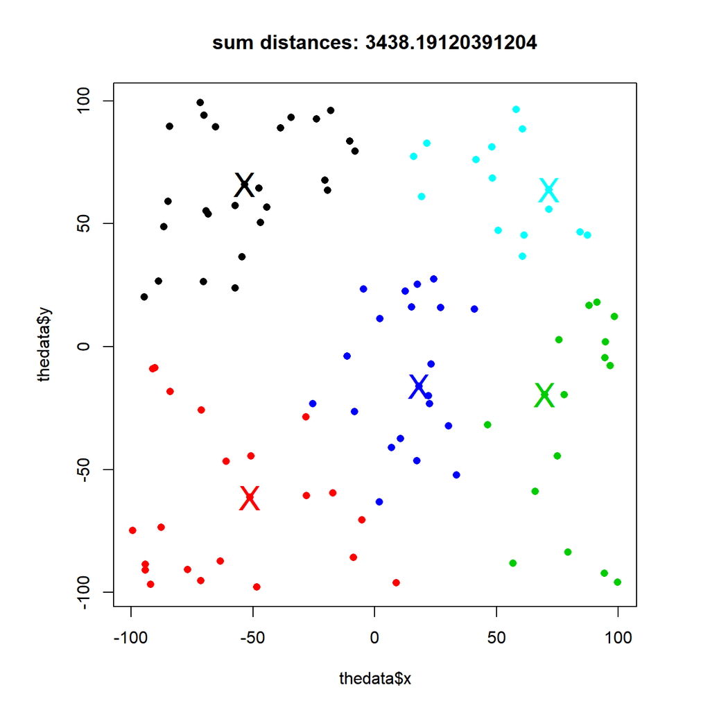

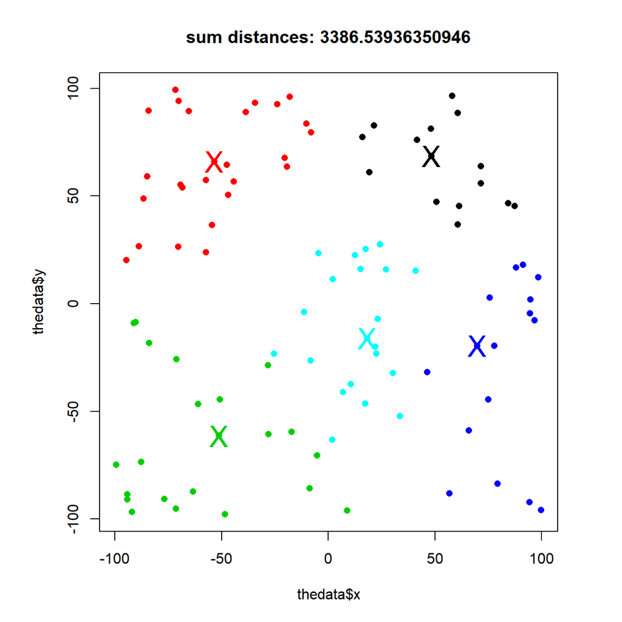

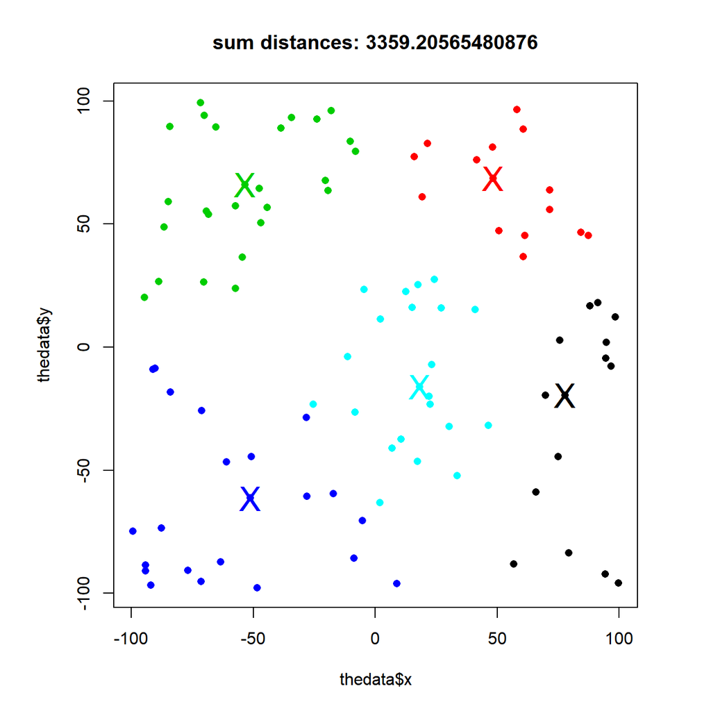

```r
prev_best_sumdist <- run_dist_calc$tot_dist
sumdist_still_improving_flag <- 1

while( sumdist_still_improving_flag == 1 ){

  # generate list of swaps to try:
  swaps_to_try_list <- list()

  non_medoid_indices <- setdiff( 1:nrow(distmat), current_medoid_indices )

  # populate the swaps_to_try_list:
  for( clustr in 1:k ){

    swaps_to_try_list[[clustr]] <-
      cbind( non_medoid_indices,
             sapply( current_medoid_indices[-clustr],
                     function(x){ rep(x, length(non_medoid_indices) ) }
                   )
            )
  }

  # bind swaps table into a single table:
  swaps_to_try <- do.call( rbind, swaps_to_try_list )

  # create a vector to store the sum of distances for each possible swap:
  swap_total_sumdist <- rep(NA, nrow(swaps_to_try) )

  # calculate sum of distances under each possible swap:
  # and store this information
  for( swap_i in 1:length(swap_total_sumdist) ){

    swap_total_sumdist[swap_i] <-
      calc_tot_within_dist( medoid_indices = swaps_to_try[swap_i, ] )$tot_dist

  }

  # identify best swap (index):
  swap_with_best_improvement <- which.min(swap_total_sumdist)

  # is the best swap better than the current clustering?
  total_dist_best_swap <-
    calc_tot_within_dist( medoid_indices = swaps_to_try[swap_with_best_improvement,] )$tot_dist

  if( prev_best_sumdist > total_dist_best_swap ){  # if the best swap improves the clustering

    # update current medoids:
    current_medoid_indices <- sort(  swaps_to_try[swap_with_best_improvement,]  )

    # assign each point to closest medoid:
    run_dist_calc <- calc_tot_within_dist( medoid_indices = current_medoid_indices )

    # update the sum of distances of best clustering found so far:
    prev_best_sumdist <- run_dist_calc$tot_dist

    # draw plot of current clustering:
    draw_current_plot()

    # print( current_medoid_indices )

  } else{    # if we can't improve our clustering with a swap

    # stop the algorithm
    sumdist_still_improving_flag <- 0

  }

}
```

Compare my final clustering result to the final result of the function cluster::pam() in R:

```r
results <- rbind( joes_calc = sort(current_medoid_indices),
                  pam_function_in_r = sort(run_pam$id.med)
                )
colnames(results) <- paste("medoid",1:ncol(results) )

results
```

```
##                   medoid 1 medoid 2 medoid 3 medoid 4 medoid 5
## joes_calc                6       16       28       50       64
## pam_function_in_r        6       16       28       50       64
```

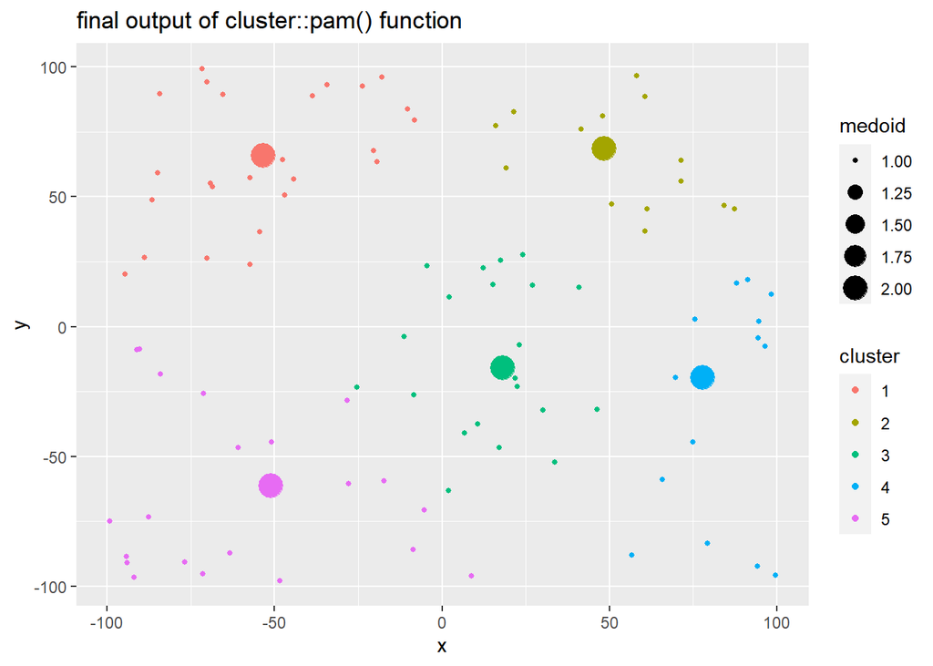

```r
ggplot( data = bind_cols( thedata, tibble( cluster = factor(run_pam$clustering) ) ) %>%
                  mutate( id = row_number() ) %>%
                  mutate( medoid = ifelse(id %in% run_pam$id.med, 2, 1) )
          ,
        aes( x=x, y=y, colour=cluster, size=medoid )
      ) +
  geom_point() +
  labs( title="final output of cluster::pam() function")
```

# Silhouette Values

- The **silhouette** value/metric is a measurement of the quality of a clustering.
- Every point (row) in the dataset receives a **silhouette** value.
- The **Silhouette** value is not specific to PAM, but can be applied to a clustering from any algorithm.
- **Silhouette** takes into account both *cohesion*/*tightness* (average distance of a point to every other point in it’s cluster) and *separation* (average distance of a point to all points in the next nearest different cluster). Both *cohesion* and *separation* are important for a good clustering.
- The **silhouette** value always falls in the range $[-1,1]$, where $-1$ is the least desirable value and $1$ the most desirable.
- The **silhouette** value can be used to identify well-performing clusters within a particular clustering, measure the overall quality of a particular clustering, and assist in choosing an optimal number of clusters to use (e.g. choice of $k$ in k-means or PAM clustering). A large number of low or negative silhouette values is a sign of a bad clustering.
- The **silhouette** value can also be used to identify points/observations which do not fit well into the cluster to which they have been assigned.
- The **Silhouette** calculation depends on the measure of distance of points from one another. Hence, it requires the choice of a distance metric (I’ve again used *euclidean distance*).
- Inferences on the quality of a particular clustering can be inferred from the distribution of **Silhouette** values within each cluster.
- The **Silhouette** value can be used to compare different clustering algorithms fit to the same data.

The steps for calculating the **silhouette** value for a given point $p$ are as follows:

$$a\Big(p\Big) \quad=\quad \displaystyle\frac{\displaystyle\sum_{\displaystyle j\in C_p}d\big(p,j\big)}{|C_p|-1}$$

$a\Big(p\Big)$ is the average distance of point $p$ from every other point in it’s cluster $C_p$

$$b\Big(p\Big) \quad=\quad \underset{\displaystyle k \neq p}{\text{min}} \quad \displaystyle\frac{\displaystyle\sum_{\displaystyle j \in C_k} d\big(p,j\big)}{|C_k|}$$

For every cluster $C_k$ that point $p$ is **not** in: the average distance between point $p$ and every point in cluster $C_k$ is calculated. $b\Big(p\Big)$ is then the smallest of these $k-1$ values calculated (i.e. it is the average distance of point $p$ to every point in the closest cluster).

The **silhouette** value of point $p$ is then:

$$\begin{array}{lcl}
\text{silhouette}\Big(p\Big)
&=&
\begin{cases}
\displaystyle\frac{b(p)-a(p)}{\text{max}\Big\{a(p),b(p)\Big\}} & \text{if } \quad |C_p|>1 \\
0 & \text{if } \quad |C_p| = 1 \quad\quad (\text{i.e. if cluster contains only point } p )
\end{cases}
\end{array}$$

The denominator term enforces that the value lies within the range [-1,1]. Intuitively, the *silhouette* is a measure of the average within-cluster distance relative to the distance to the nearest cluster.

Consider the following clustered data:

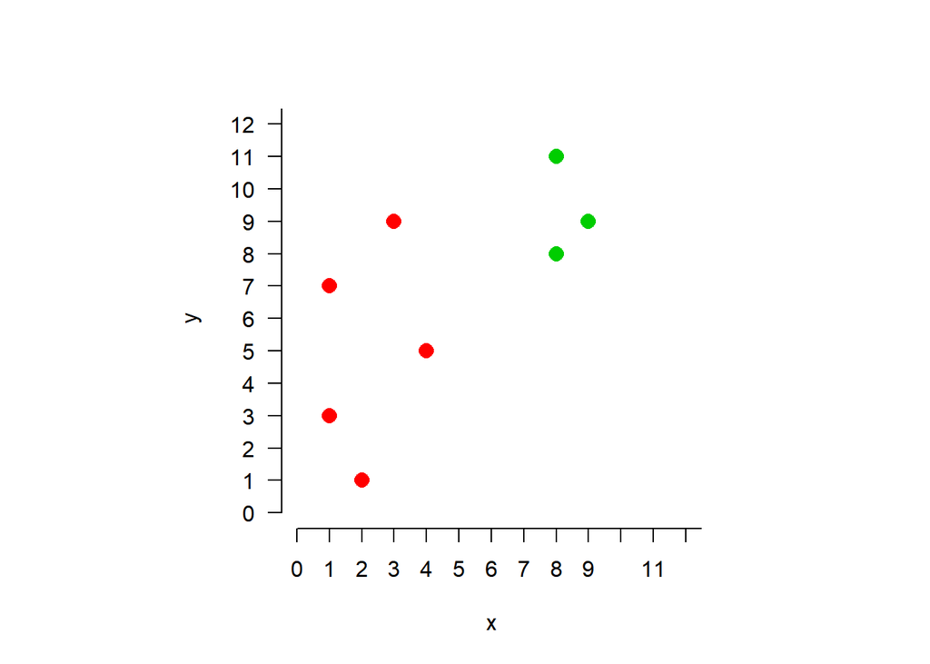

We are going to calculate the silhouette value for this point ‘$p$’ :

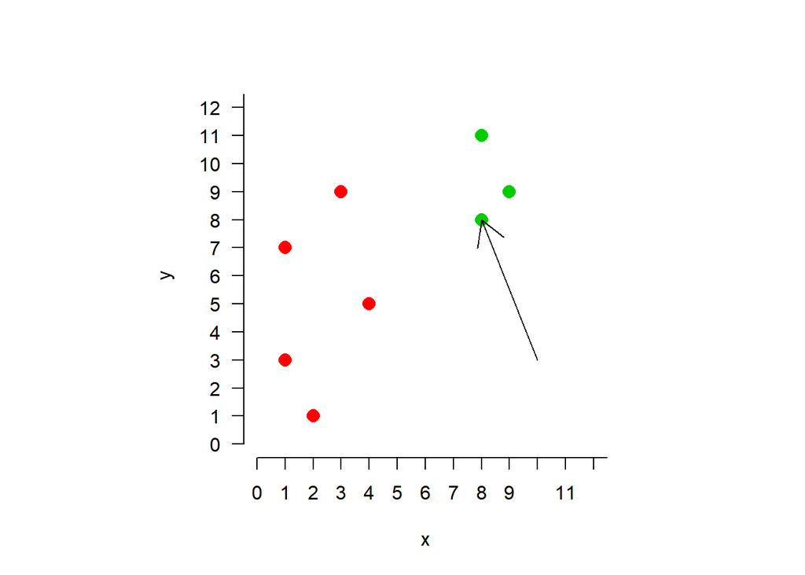

The euclidean distances between this point and the other points in its own cluster are:

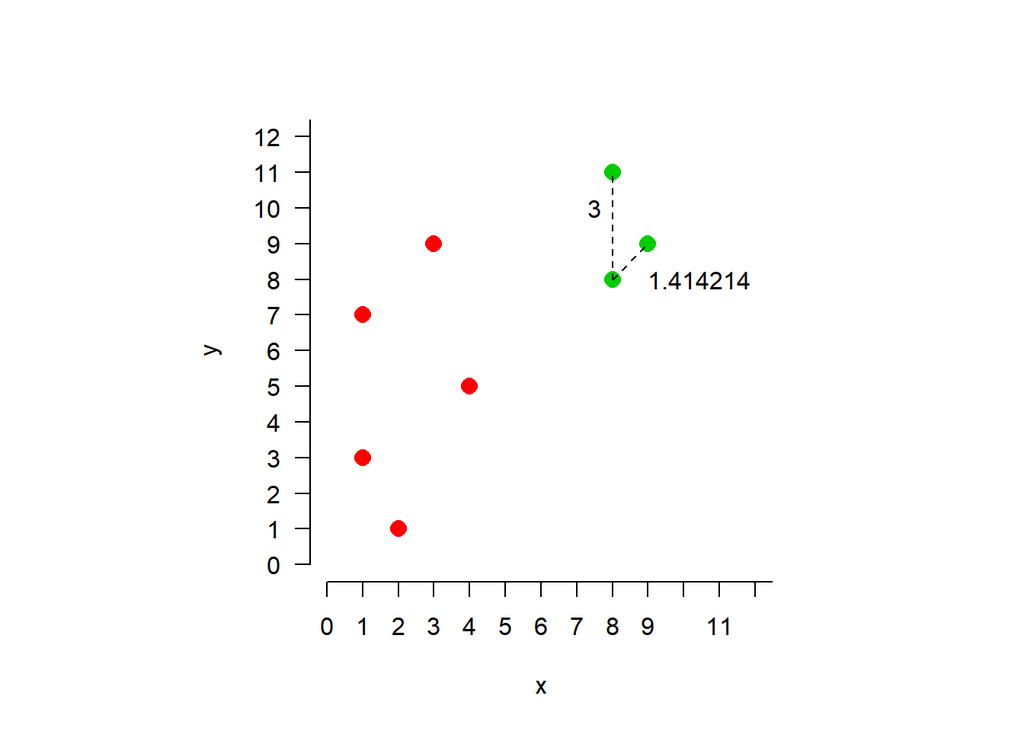

SO, the average distance $a(p)$ of $p$ from the other points in it’s cluster is

$$a(p) \quad=\quad\displaystyle\frac{3+1.414214}{2} \quad=\quad 2.207107$$

The distances from $p$ to the points in the next nearest cluster are:

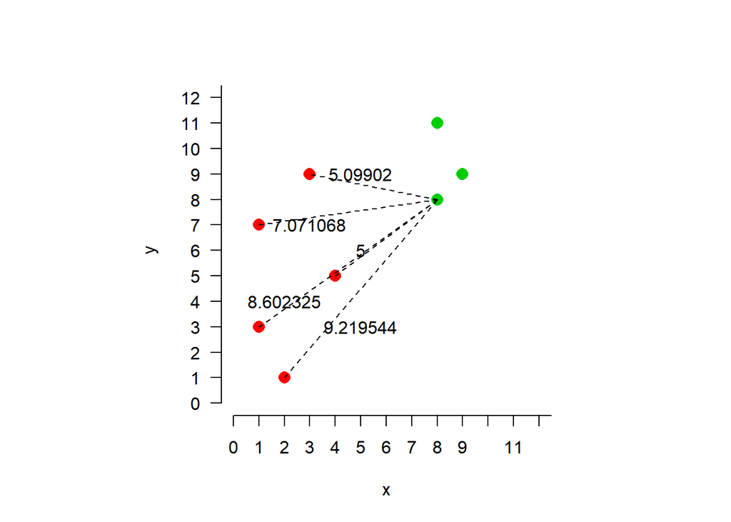

The makes the silhouette value for point $p$

$$\begin{array}{lcl}
\text{silhouette}(p)
&=& \displaystyle\frac{b(p)-a(p)}{\text{max}\Big\{a(p),b(p)\Big\}} \\
&=& \displaystyle\frac{6.998391-2.207107}{\text{max}\Big\{2.207107, 6.998391\Big\}} \\
&=& 0.6846265 \\
\end{array}$$

The silhouette values for all of the points are:

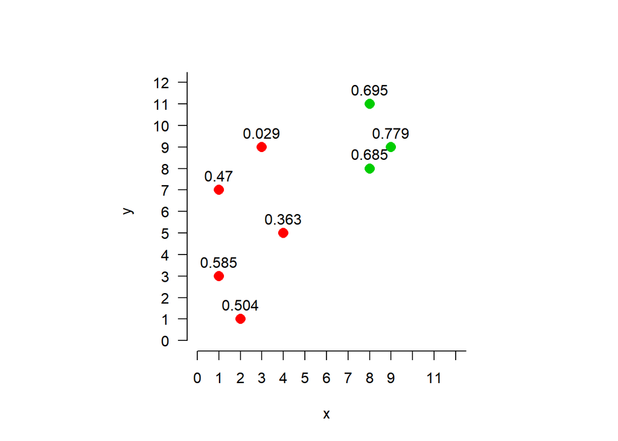

Notice how the *silhouette* values measure both *separation* (distance from next nearest cluster) and *tightness* (closeness to own cluster), where the measure is relative to the average distance to the nearest cluster.

Here is an example of how a silhouette value can be negative (the value is -0.05):

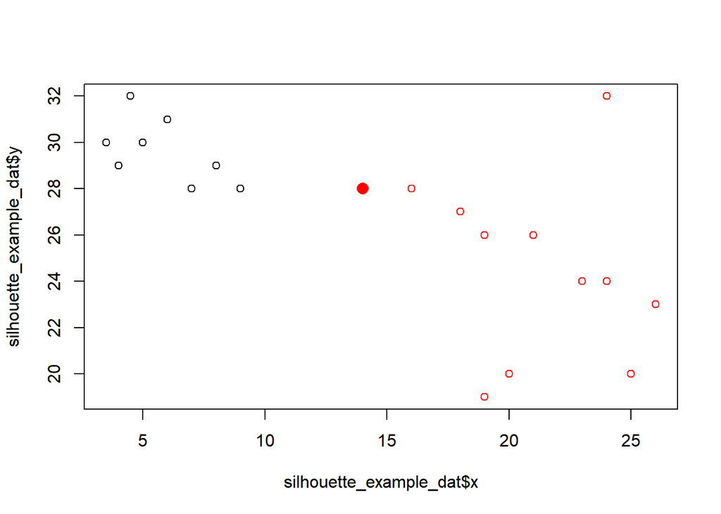

```r
silhouette_example_dat <-
  tibble( x = c(3.5,  4,  4.5,  5,  6,  7,  9,  8,  14,                 16, 18, 19, 21, 23, 24, 26, 20, 19, 25, 24 ),
          y = c(30,  29,  32,  30,  31, 28, 28, 29, 28,                 28, 27, 26, 26, 24, 24, 23, 20, 19, 20, 32  ),
          cluster = c( rep(1, 8), rep(2,12) )
        )
plot( x = silhouette_example_dat$x,
      y = silhouette_example_dat$y,
      col = silhouette_example_dat$cluster
     )
points( x = 14, y=28, col=2, pch=16, cex=1.5 )
```

```r
cluster::silhouette( x = silhouette_example_dat$cluster,
                     dist = dist(silhouette_example_dat[,c("x","y")], method = "euclidean")
                   )[9,"sil_width"]
```

```
##   sil_width
## -0.05251089
```

Here is my manual calculation of the **silhouette** values of all points in the PAM clustering done at the beginning of this post:

```r
# store matrix of euclidean distances between all of the points:
distmat <- as.matrix( dist(thedata[,c("x","y")], method = "euclidean") )

# create a table in which to do the calculation (currently filled with blank values):
joe_silhouette_calc <- cbind( id = 1:nrow(distmat),    # assign a unique ID to every point 'p'
                              cluster = run_pam$clustering,   # cluster assigned to point p
                              a = rep( as.numeric(NA), nrow(distmat) ),   # average distance within own cluster
                              b = rep( as.numeric(NA), nrow(distmat) ),   # average dist to closest neighbour cluster
                              neighbour = rep( as.integer(NA), nrow(distmat) ),  # cluster number of closest neighbour cluster
                              sil_width = rep( as.numeric(NA), nrow(distmat) )   # silhouette value
                            ) %>%
  as_tibble()

for( p in 1:nrow(joe_silhouette_calc) ){    # for each point (row in the table)

  # get the cluster number of this point:
  cluster_of_p <- joe_silhouette_calc[p,"cluster"] %>% pull(cluster)

  # pull out the row of the distance matrix corresponding to point p:
  p_row_distmat <- distmat[p, which(joe_silhouette_calc$cluster==cluster_of_p) ]

  # get [a]: mean within cluster distance from this point:
  joe_silhouette_calc[p,"a"] <- sum( p_row_distmat ) / ( length(p_row_distmat)-1 )

  # for all other clusters, get mean distance to point p:
  store_b_per_other_cluster <- rep( NA, k-1 )        # create empty vector to store the distances in

  # get a list of names of the other clusters (i.e. all clusters not containing p):
  other_cluster_nums <-
    joe_silhouette_calc %>% filter(cluster != cluster_of_p) %>% distinct(cluster) %>% pull(cluster)

  # calculate the average distance to point p for every cluster and store this info in 'store_b_per_other_cluster':
  for( c in other_cluster_nums ){
    store_b_per_other_cluster[ which(other_cluster_nums==c) ] <-
      mean( distmat[p, which(joe_silhouette_calc$cluster==c)] )
  }

  # record which cluster is closest to point p (has smallest average distance to p):
  joe_silhouette_calc[p, "neighbour"] <- other_cluster_nums[ which.min(store_b_per_other_cluster) ]

  # calculate b[p] for this point (average distance to closest neighbour cluster)
  joe_silhouette_calc[p, "b"] <- store_b_per_other_cluster[ which.min(store_b_per_other_cluster) ]

}

joe_silhouette_calc <-
    joe_silhouette_calc %>%
      mutate( sil_width = case_when( a < b ~ 1 - a/b,
                                     a > b ~ b/a - 1,
                                     a == b ~ 0,
                                     TRUE ~ as.numeric(NA)
                                    )
      )
```

Compare my silhouette calculation to those produced by the R function cluster::silhouette():

```r
get_silhouette <-
  cluster::silhouette( x = run_pam$clustering,
                       dist = dist(thedata[,c("x","y")], method = "euclidean")
                     )

joe_silhouette_calc %>%
  select( id, sil_width ) %>%
  rename( joe_silhouette_val = sil_width ) %>%
  bind_cols( tibble( R_silhouette_val = get_silhouette[,3]) )
```

| id | joe_silhouette_val | R_silhouette_val |
| --- | --- | --- |
| 1 | 0.39225410 | 0.39225410 |
| 2 | 0.46319596 | 0.46319596 |
| 3 | 0.15934278 | 0.15934278 |
| 4 | 0.19707837 | 0.19707837 |
| 5 | 0.65134404 | 0.65134404 |
| 6 | 0.40974818 | 0.40974818 |
| 7 | 0.66579020 | 0.66579020 |
| 8 | -0.15349305 | -0.15349305 |
| 9 | 0.63907445 | 0.63907445 |
| 10 | 0.30938631 | 0.30938631 |

[output cut: 90 more lines]

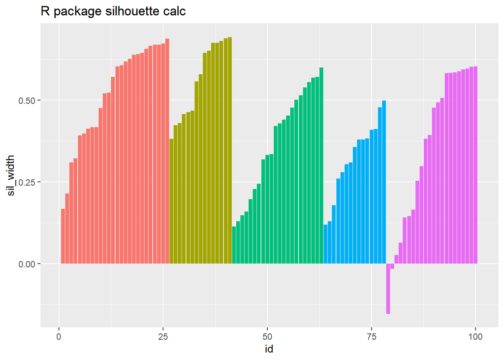

```r
# R silhouette calc plot:
get_silhouette <- tibble( cluster = get_silhouette[,"cluster"],
                         neighbor = get_silhouette[,"neighbor"],
                         sil_width = get_silhouette[,"sil_width"]
                       ) %>%
 arrange( cluster, sil_width ) %>%
 mutate( id = row_number() )

ggplot( data = get_silhouette,
       aes( x = id,
            y = sil_width,
            fill = as.factor(cluster)
           )
     ) +
 geom_bar( stat="identity" ) +
 theme( legend.position = "none" ) +
 labs( title = "R package silhouette calc")
```

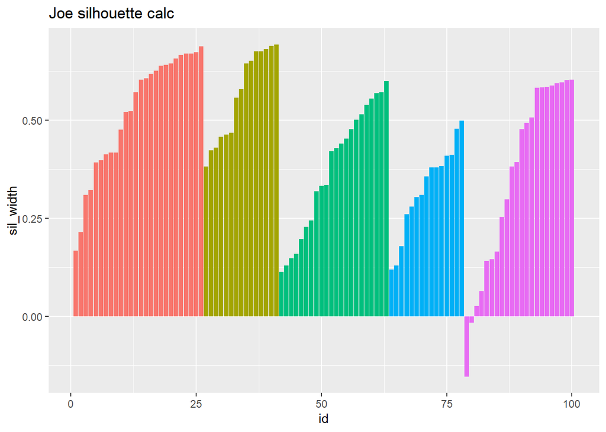

```r
# my manual silhouette calc plot:
joe_silhouette_calc %>%
  mutate( sil_width = case_when( a < b ~ 1 - a/b,
                                 a > b ~ b/a - 1,
                                 a == b ~ 0,
                                 TRUE ~ as.numeric(NA)
                                )
  ) %>%
 arrange( cluster, sil_width ) %>%
 mutate( id = row_number() ) %>%

ggplot( data = . ,
       aes( x = id,
            y = sil_width,
            fill = as.factor(cluster)
           )
     ) +
 geom_bar( stat="identity" ) +
 theme( legend.position = "none" ) +
 labs( title = "Joe silhouette calc")
```

# Exploring binning/categorizing data before using it for clustering:

As a tiny note, to be explored fully in a later post, I am very interested in the effect of binning continuous variables into ranked factors/categories and then applying clustering to these binned variables instead.

This makes the clustering focus on creating clusters that are easy to interpret (e.g. *this cluster contains mostly customers who spent over $1,000*), and could also be used to deal with outliers .

In the example below, the variables **spend** and **frequency** are first binned into convenient categories. The categories are then ranked, and these ranks are used as numeric variables in the clustering (these are called **spend_rank** and **freq_rank** in the example below). This makes the distance between points based on how many category bins they are away from another (e.g. *spend_rank=3* is two spend categories away from *spend_rank=1*). Notice how the clustering based on the variables **spend_rank** and **freq_rank**, rather than **spend** and **frequency**, clusters points into clearly-defined square bins.

```r
set.seed(13)
bindata <-
  tibble( customer_id = 1:100 ) %>%
    mutate( frequency_type = sample( c("low", "medium","high"), size=n(), replace=TRUE ),
            avg_spend_type = sample( c("low", "medium","high"), size=n(), replace=TRUE )
    ) %>%
  mutate( frequency = case_when( frequency_type == "low" ~ round( runif( n(), 1, 5 ) ),
                                 frequency_type == "medium" ~ round( runif( n(), 1, 20 ) ),
                                 frequency_type == "high" ~ round( runif( n(), 1, 100 ) ),
                                 TRUE ~ -99
                                ),
          spend = case_when( avg_spend_type == "low" ~ round( runif( n(), 10, 5000 ) ),
                                 avg_spend_type == "medium" ~ round( runif( n(), 10, 10000 ) ),
                                 avg_spend_type == "high" ~ round( runif( n(), 10, 50000 ) ),
                                 TRUE ~ -99
                                )
        )

bindata$freq_bin <- cut( bindata$frequency, breaks = c(0,25,50,100), include.lowest = TRUE )
bindata$freq_rank <- as.numeric(bindata$freq_bin)
bindata$spend_bin <- cut( bindata$spend/10000, breaks = c(0,1,2,5), include.lowest = TRUE )
bindata$spend_rank <- as.numeric(bindata$spend_bin)

bindata
```

| customer_id | frequency_type | avg_spend_type | frequency | spend | freq_bin | freq_rank | spend_bin | spend_rank |
| --- | --- | --- | --- | --- | --- | --- | --- | --- |
| 1 | high | low | 42 | 3721 | (25,50] | 2 | [0,1] | 1 |
| 2 | low | medium | 2 | 6205 | [0,25] | 1 | [0,1] | 1 |
| 3 | medium | low | 9 | 2228 | [0,25] | 1 | [0,1] | 1 |
| 4 | low | low | 4 | 3668 | [0,25] | 1 | [0,1] | 1 |
| 5 | medium | high | 12 | 24010 | [0,25] | 1 | (2,5] | 3 |
| 6 | medium | high | 17 | 18328 | [0,25] | 1 | (1,2] | 2 |
| 7 | low | low | 3 | 2619 | [0,25] | 1 | [0,1] | 1 |
| 8 | high | low | 73 | 401 | (50,100] | 3 | [0,1] | 1 |
| 9 | low | medium | 2 | 204 | [0,25] | 1 | [0,1] | 1 |
| 10 | medium | high | 1 | 775 | [0,25] | 1 | [0,1] | 1 |

[output cut: 90 more lines]

```r
bindata %>% distinct(freq_bin, freq_rank) %>% arrange(freq_rank)
```

| freq_bin | freq_rank |
| --- | --- |
| [0,25] | 1 |
| (25,50] | 2 |
| (50,100] | 3 |

```r
bindata %>% distinct(spend_bin, spend_rank) %>% arrange(spend_rank)
```

| spend_bin | spend_rank |
| --- | --- |
| [0,1] | 1 |
| (1,2] | 2 |
| (2,5] | 3 |

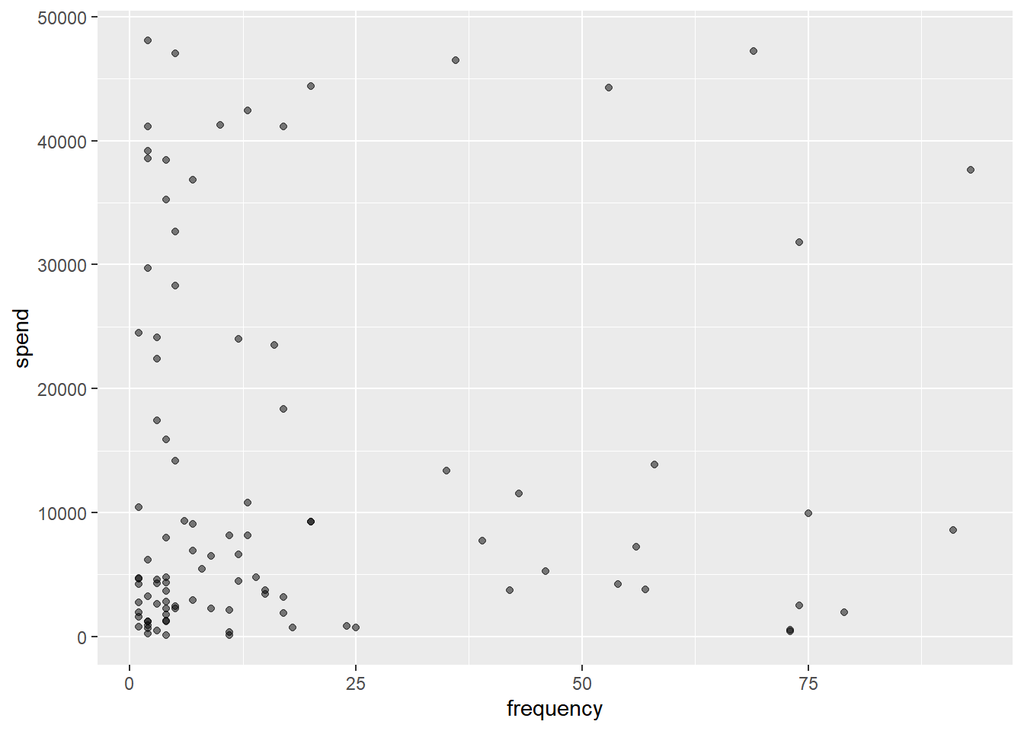

```r
ggplot( data = bindata,
        aes( x = frequency, y = spend )
      ) +
  geom_point( alpha=0.5 )
```

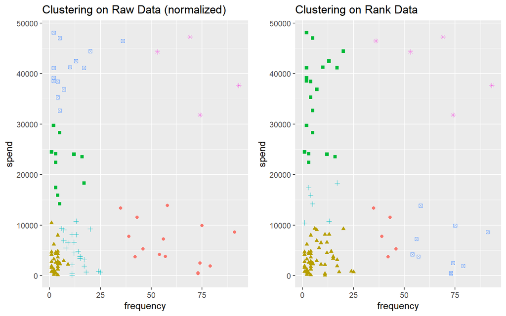

```r
PAMS_on_raw_data <-
  cluster::pam( x = bindata %>% select(frequency, spend) %>% scale(),
                k = 6,
                metric = "euclidean",
                diss = FALSE,
                stand = FALSE,
                pamonce = 0
              )

PAMS_on_ranked_bins <-
  cluster::pam( x = bindata %>% select(freq_rank, spend_rank),
                k = 6,
                metric = "euclidean",
                diss = FALSE,
                stand = FALSE,
                pamonce = 0
              )

ggpubr::ggarrange(

  ggplot( data = bind_cols( bindata,
                            tibble( cluster = as.factor(PAMS_on_raw_data$clustering) )
                          ),
          aes( x = frequency, y = spend, colour=cluster, shape=cluster )
      ) +
  geom_point() +
  theme( legend.position="none" ) +
  labs( title = "Clustering on Raw Data (normalized)")

  ,

  ggplot( data = bind_cols( bindata,
                            tibble( cluster = as.factor(PAMS_on_ranked_bins$clustering) )
                          ),
          aes( x = frequency, y = spend, colour=cluster, shape=cluster )
      ) +
  geom_point() +
  theme( legend.position="none" ) +
  labs( title = "Clustering on Rank Data")

)
```

# CLARA: [C]lustering [LAR]ge [A]pplications algorithm

For large datasets (more than a few thousand points), the k-medoids PAM algorithm is infeasible - it will simply take too long to run.

For this reason, there are a number of variants and extensions to the PAM algorithm designed to be used on larger datasets. One of these is CLARA, which is implemented as follows:

**CLARA**

1 Find several candidate sets of *medoids* by doing PAM clustering repeatedly on multiple different random subsets of the data (of chosen size, as large as possible).

2 Choose the set of *medoids* out of all of the candidate sets identified that perform best on the entire (global) dataset (minimise the sum of distances of each point to it’s *medoid*).

3 Proceeding with the chosen set of *medoids*: Clusters are obtained by assigning points in the global dataset to their closest *medoid*.

# References

the original PAM paper:

- https://www.researchgate.net/publication/243777819_Clustering_by_Means_of_Medoids

other resources that I used:

- https://en.wikipedia.org/wiki/K-medoids
- https://en.wikipedia.org/wiki/Silhouette_(clustering)